# Comparing larval size by parental treatment

Laura H Spencer

9/6/2019

#### Load libraries

```r
library(ggplot2)
library(dplyr)
library(car)
library(arm)
```

#### Load data and reformat

```r
larvae.size <- read.csv("../data/2019-08_new-larvae-measurements.csv", header=T, stringsAsFactors = F)
larvae.size[c("Sample", "Population", "Temperature", "pH")] <- lapply(larvae.size[c("Sample", "Population", "Temperature", "pH")], factor)
larvae.size$DateCollected <- as.Date(larvae.size$DateCollected, format = "%m/%d/%y")
```

#### Correct size data

Scope was not calibrated accurately. Based on measurements of 12 known lengths, multiply lengths by 1.405669

MaxFeret = best estimate of shell width (length running parallel to hinge) MinFeret = best estimate of shell heigh (length running perpendicular to hinge)

```r
larvae.size$MaxFeret.cor <- larvae.size$MaxFeret*1.405669
larvae.size$MinFeret.cor <- larvae.size$MinFeret*1.405669
```

Inspect size data

```r
summary(larvae.size[c("Length", "Width", "MaxFeret", "MinFeret", "MaxFeret90", "MaxFeret.cor", "MinFeret.cor")])
```

```
##      Length           Width           MaxFeret         MinFeret
##  Min.   : 82.53   Min.   : 39.70   Min.   : 82.53   Min.   : 57.6
##  1st Qu.:122.88   1st Qu.: 82.92   1st Qu.:123.11   1st Qu.:108.9
##  Median :127.11   Median : 86.28   Median :127.33   Median :112.7
##  Mean   :128.51   Mean   : 85.59   Mean   :127.65   Mean   :112.5
##  3rd Qu.:131.82   3rd Qu.: 89.44   3rd Qu.:131.74   3rd Qu.:116.4
##  Max.   :199.16   Max.   :112.46   Max.   :168.36   Max.   :136.8
##    MaxFeret90      MaxFeret.cor    MinFeret.cor
##  Min.   : 61.83   Min.   :116.0   Min.   : 80.97
##  1st Qu.:111.67   1st Qu.:173.0   1st Qu.:153.01
##  Median :115.68   Median :179.0   Median :158.43
##  Mean   :115.69   Mean   :179.4   Mean   :158.11
##  3rd Qu.:119.74   3rd Qu.:185.2   3rd Qu.:163.62
##  Max.   :141.92   Max.   :236.7   Max.   :192.30
```

```r
aggregate(MaxFeret.cor ~ Temperature+pH, larvae.size, mean)
```

```
##   Temperature      pH MaxFeret.cor
## 1           6 ambient     175.2853
## 2          10 ambient     179.9303
## 3           6     low     178.4324
## 4          10     low     184.4304
```

```r
aggregate(MinFeret.cor ~ Temperature+pH, larvae.size, mean)
```

```
##   Temperature      pH MinFeret.cor
## 1           6 ambient     155.3373
## 2          10 ambient     158.2066
## 3           6     low     157.1796
## 4          10     low     162.3682
```

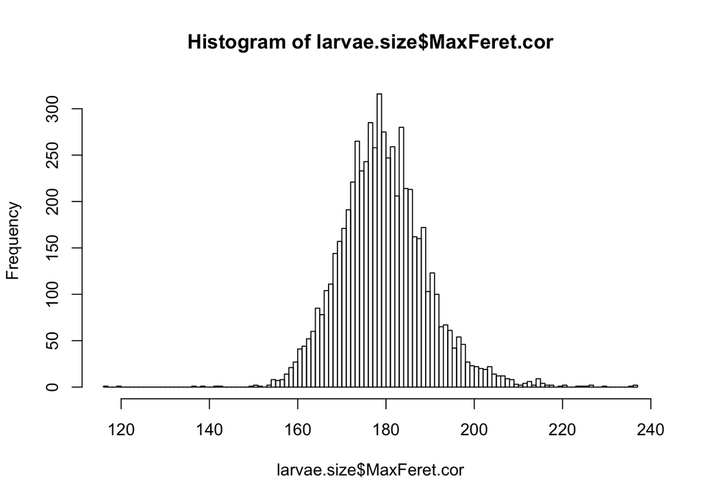

```r
hist(larvae.size$MaxFeret.cor, breaks = 100)
```

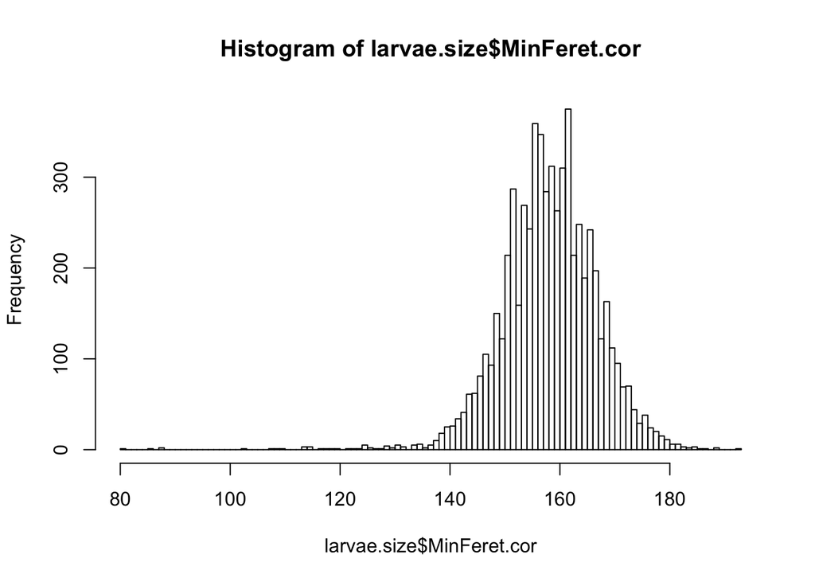

```r
hist(larvae.size$MinFeret.cor, breaks = 100)
```

#### How many samples do I have size data for, per group?

The number of larval samples, which were collect from volitional spawn w/n treatments, is unequal among treatments. Unbalanced design (need to account for this in stats)

Cohort + Temperature + pH

```r
larvae.size %>%
          group_by(Population, Temperature, pH) %>%
          summarise(count= n_distinct(Sample))
```

```
## # A tibble: 16 x 4
## # Groups:   Population, Temperature [8]
##    Population    Temperature pH      count
##    <fct>         <fct>       <fct>   <int>
##  1 Dabob Bay     6           ambient     1
##  2 Dabob Bay     6           low         3
##  3 Dabob Bay     10          ambient     4
##  4 Dabob Bay     10          low         4
##  5 Fidalgo Bay   6           ambient     2
##  6 Fidalgo Bay   6           low         7
##  7 Fidalgo Bay   10          ambient     5
##  8 Fidalgo Bay   10          low         3
##  9 Oyster Bay C1 6           ambient     5
## 10 Oyster Bay C1 6           low         8
## 11 Oyster Bay C1 10          ambient    12
## 12 Oyster Bay C1 10          low         6
## 13 Oyster Bay C2 6           ambient     4
## 14 Oyster Bay C2 6           low         5
## 15 Oyster Bay C2 10          ambient     3
## 16 Oyster Bay C2 10          low         3
```

Just Temperature + pH (all cohorts combined - how i will assess)

```r
larvae.size %>%
          group_by(Temperature, pH) %>%
          summarise(count= n_distinct(Sample))
```

```
## # A tibble: 4 x 3
## # Groups:   Temperature [2]
##   Temperature pH      count
##   <fct>       <fct>   <int>
## 1 6           ambient    12
## 2 6           low        23
## 3 10          ambient    24
## 4 10          low        16
```

### Generate initial plots

Inspect all larval length data (not yet summarized for each larval group)

- Shell width ~ shell height, color coded by parental treatment
- Shell width by parental treatment within each cohort
- Shell height by parental treatment within each cohort

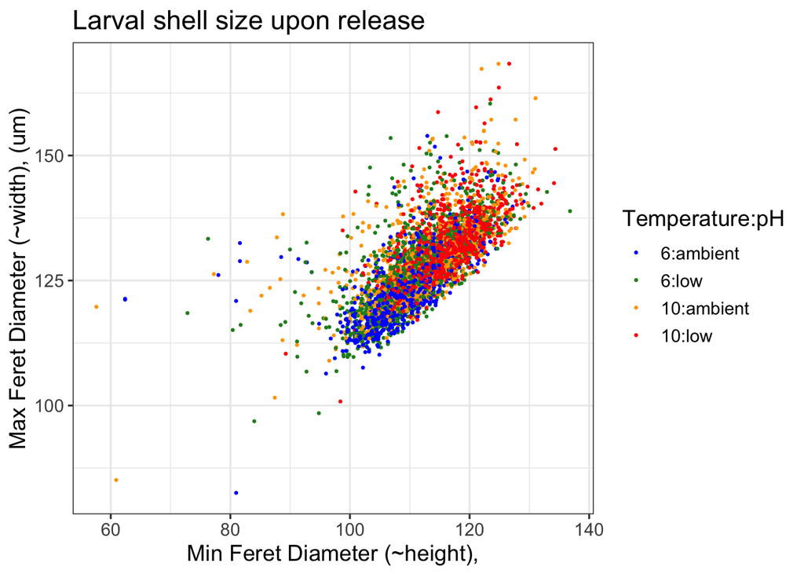

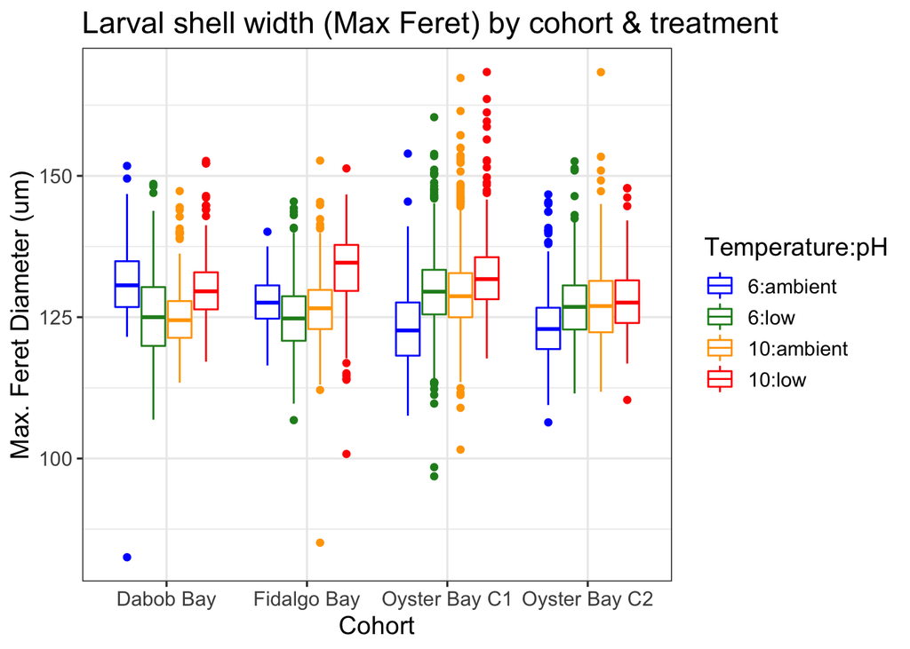

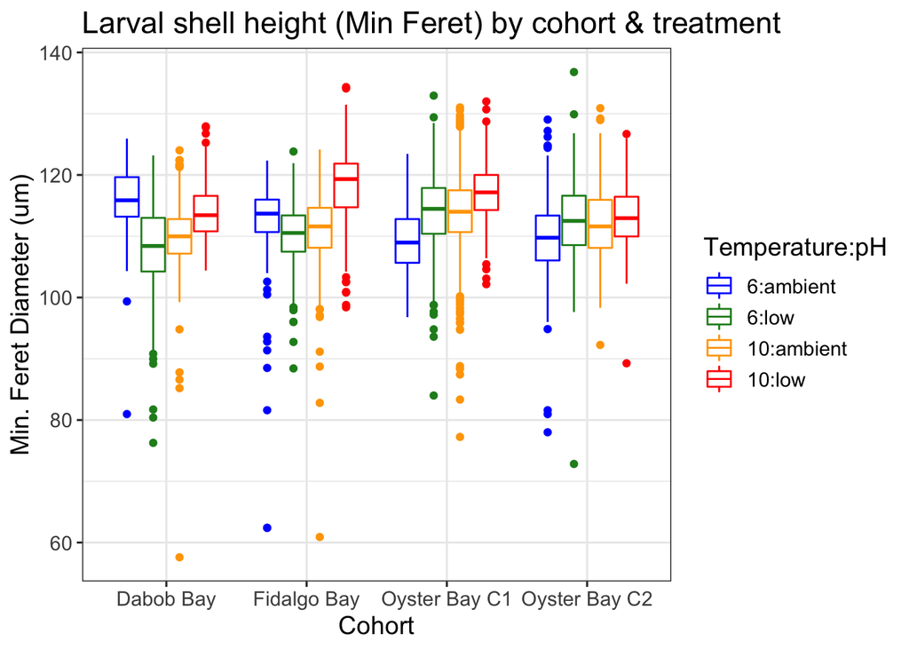

#### Save plots

```r
png("../plots/larval-max-min-all.png")
max.min.all
dev.off()
png("../plots/larval-max-feret-all.png")
max.all
dev.off()
png("../plots/larval-min-feret-all.png")
min.all
dev.off()
```

#### Summarize mean shell height and width for each larval sample

```r
larvae.size.mean <- larvae.size %>%
          group_by(Population, Temperature, pH, Sample) %>%
          summarise(MaxFeret.mean=mean(MaxFeret.cor), MinFeret.mean=mean(MinFeret.cor), date=median(DateCollected))
```

#### Generate plots with average length by parental treatment

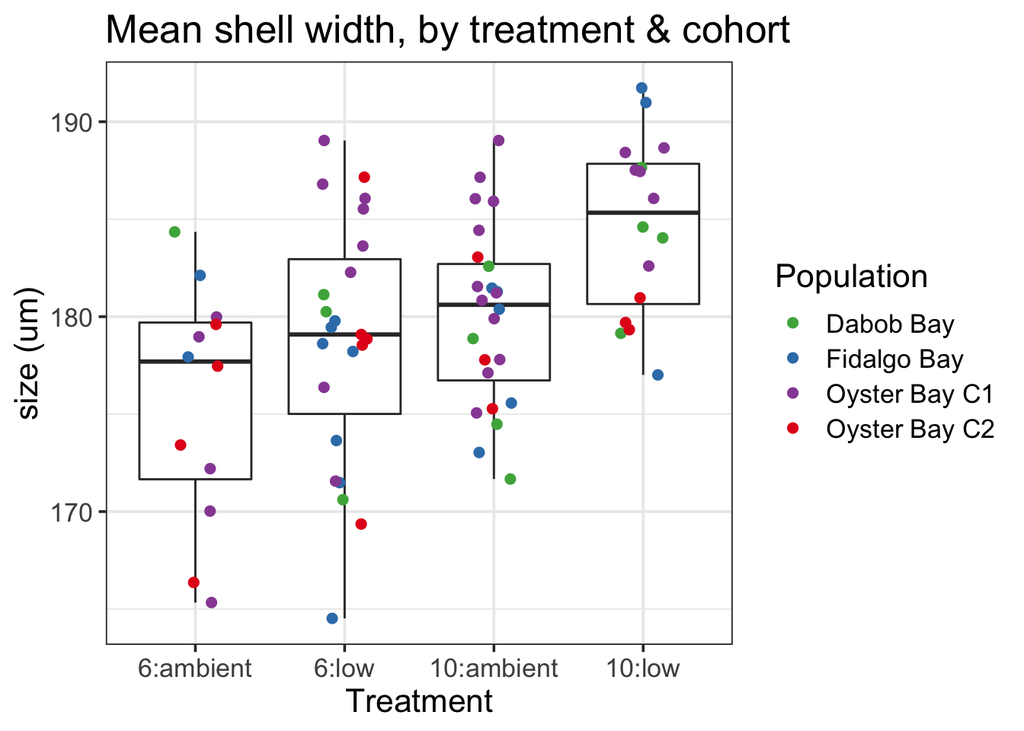

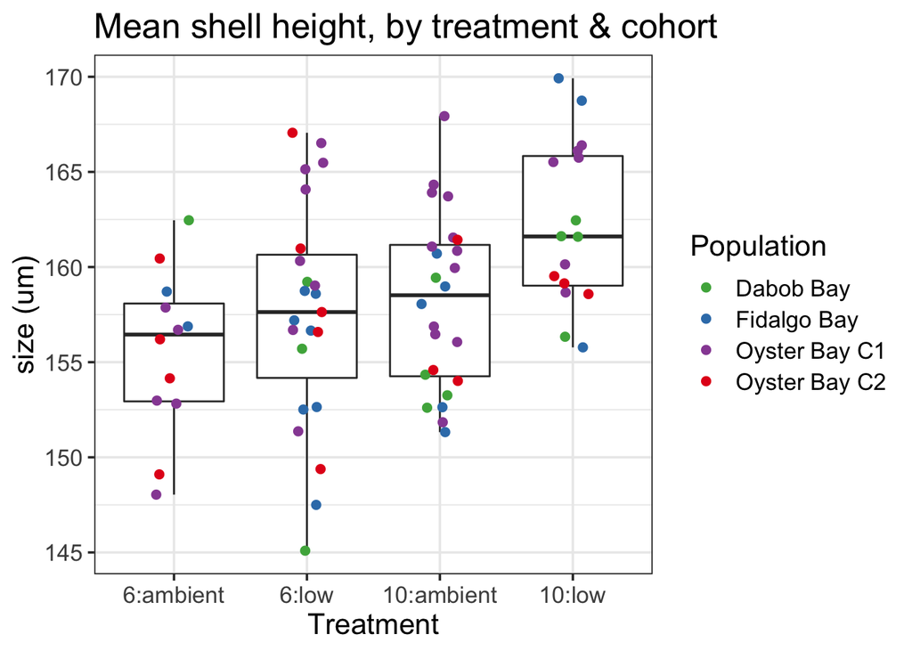

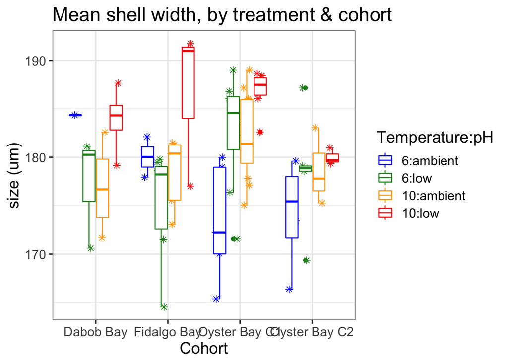

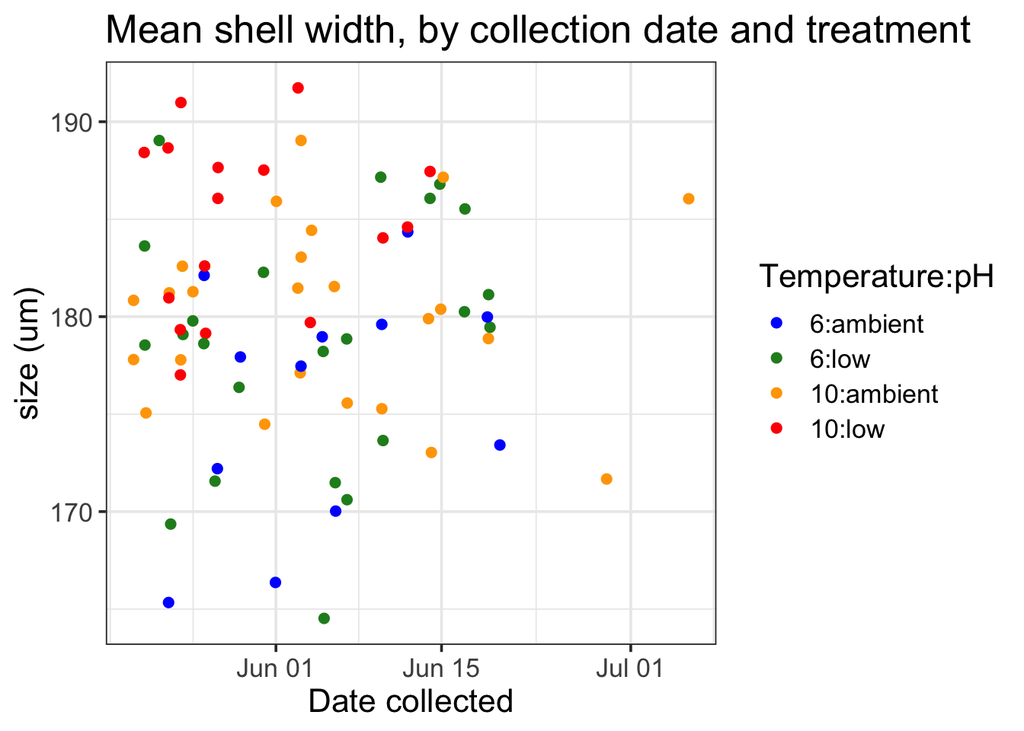

#### Save plots

```r
png("../plots/larval-max-feret-mean.png")
min.mean
dev.off()
png("../plots/larval-min-feret-mean.png")
max.mean
dev.off()
png("../plots/larval-max-feret-mean-cohort.png")
max.mean.cohort
dev.off()
png("../plots/larval-max-feret-mean-date.png")
max.mean.date
dev.off()
```

## Statistical analyses

Test for length differences among parental temp, pH treats

NOTE: unbalanced design, so need to use either Type II or Type III SS. See nice explanation here: https://www.r-bloggers.com/anova-%E2%80%93-type-iiiiii-ss-explained/

#### Test Max. Feret Diameter (best estimate for larval width)

Check ANOVA assumptions

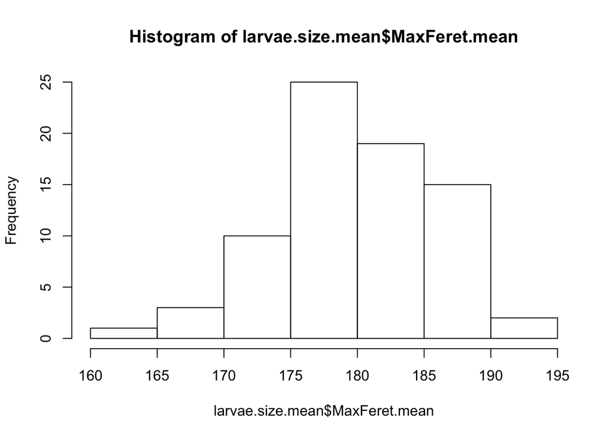

```r
hist(larvae.size.mean$MaxFeret.mean)
```

```r
shapiro.test(larvae.size.mean$MaxFeret.mean)
```

```
##
##  Shapiro-Wilk normality test
##
## data:  larvae.size.mean$MaxFeret.mean
## W = 0.97849, p-value = 0.2311
```

```r
bartlett.test(MaxFeret.mean ~ pH, data=larvae.size.mean)
```

```
##
##  Bartlett test of homogeneity of variances
##
## data:  MaxFeret.mean by pH
## Bartlett's K-squared = 0.74067, df = 1, p-value = 0.3894
```

```r
bartlett.test(MaxFeret.mean ~ Temperature, data=larvae.size.mean)
```

```
##
##  Bartlett test of homogeneity of variances
##
## data:  MaxFeret.mean by Temperature
## Bartlett's K-squared = 1.8339, df = 1, p-value = 0.1757
```

```r
anova(lm(MaxFeret.mean ~ Temperature + pH + Temperature:pH, data=larvae.size.mean)) #no interaction. Assess using type II sums of squares, where I look at effects of pH and temperature after controlling for the other factor
```

```
## Analysis of Variance Table
##
## Response: MaxFeret.mean
##                Df  Sum Sq Mean Sq F value   Pr(>F)
## Temperature     1  333.71  333.71 11.3795 0.001206 **
## pH              1  277.41  277.41  9.4595 0.002982 **
## Temperature:pH  1   10.32   10.32  0.3518 0.554957
## Residuals      71 2082.11   29.33
## ---
## Signif. codes:  0 '***' 0.001 '**' 0.01 '*' 0.05 '.' 0.1 ' ' 1
```

```r
Anova(lm(MaxFeret.mean ~ Temperature*pH, data=larvae.size.mean), type=2) #both sign.
```

```
## Anova Table (Type II tests)
##
## Response: MaxFeret.mean
##                 Sum Sq Df F value    Pr(>F)
## Temperature     481.01  1 16.4025 0.0001291 ***
## pH              277.41  1  9.4595 0.0029817 **
## Temperature:pH   10.32  1  0.3518 0.5549571
## Residuals      2082.11 71
## ---
## Signif. codes:  0 '***' 0.001 '**' 0.01 '*' 0.05 '.' 0.1 ' ' 1
```

```r
summary(lm(MaxFeret.mean ~ Temperature+pH, data=larvae.size.mean)) # Fit not great, though
```

```
##
## Call:
## lm(formula = MaxFeret.mean ~ Temperature + pH, data = larvae.size.mean)
##
## Residuals:
##      Min       1Q   Median       3Q      Max
## -14.5506  -3.9925   0.3832   3.9824   9.9646
##
## Coefficients:
##               Estimate Std. Error t value Pr(>|t|)
## (Intercept)    175.090      1.244 140.724  < 2e-16 ***
## Temperature10    5.252      1.291   4.068  0.00012 ***
## pHlow            3.983      1.289   3.090  0.00285 **
## ---
## Signif. codes:  0 '***' 0.001 '**' 0.01 '*' 0.05 '.' 0.1 ' ' 1
##
## Residual standard error: 5.391 on 72 degrees of freedom
## Multiple R-squared:  0.226,  Adjusted R-squared:  0.2045
## F-statistic: 10.51 on 2 and 72 DF,  p-value: 9.859e-05
```

Try mixed effect model, with Population as random effect

```r
display(lmer(MaxFeret.mean ~ Temperature*pH + (1|Population), data=larvae.size.mean))
```

```
## lmer(formula = MaxFeret.mean ~ Temperature * pH + (1 | Population),
##     data = larvae.size.mean)
##                     coef.est coef.se
## (Intercept)         175.37     1.68
## Temperature10         4.20     1.88
## pHlow                 3.23     1.88
## Temperature10:pHlow   1.68     2.54
##
## Error terms:
##  Groups     Name        Std.Dev.
##  Population (Intercept) 1.36
##  Residual               5.27
## ---
## number of obs: 75, groups: Population, 4
## AIC = 463.2, DIC = 470.7
## deviance = 461.0
```

```r
Anova(lmer(MaxFeret.mean ~ Temperature*pH + (1|Population), data=larvae.size.mean), type=2)
```

```
## Analysis of Deviance Table (Type II Wald chisquare tests)
##
## Response: MaxFeret.mean
##                  Chisq Df Pr(>Chisq)
## Temperature    16.1550  1  5.836e-05 ***
## pH             10.8203  1   0.001004 **
## Temperature:pH  0.4393  1   0.507456
## ---
## Signif. codes:  0 '***' 0.001 '**' 0.01 '*' 0.05 '.' 0.1 ' ' 1
```

```r
display(lmer(MaxFeret.mean ~ Temperature+pH+ (1|Population), data=larvae.size.mean))
```

```
## lmer(formula = MaxFeret.mean ~ Temperature + pH + (1 | Population),
##     data = larvae.size.mean)
##               coef.est coef.se
## (Intercept)   174.77     1.40
## Temperature10   5.11     1.27
## pHlow           4.16     1.26
##
## Error terms:
##  Groups     Name        Std.Dev.
##  Population (Intercept) 1.34
##  Residual               5.25
## ---
## number of obs: 75, groups: Population, 4
## AIC = 465.4, DIC = 467.5
## deviance = 461.4
```

```r
Anova(lmer(MaxFeret.mean ~ Temperature+pH + (1|Population), data=larvae.size.mean), type=2) #with Pop as random effect and using type II SS, still sign. influence of temp and pH
```

```
## Analysis of Deviance Table (Type II Wald chisquare tests)
##
## Response: MaxFeret.mean
##              Chisq Df Pr(>Chisq)
## Temperature 16.285  1  5.449e-05 ***
## pH          10.893  1  0.0009651 ***
## ---
## Signif. codes:  0 '***' 0.001 '**' 0.01 '*' 0.05 '.' 0.1 ' ' 1
```

#### Test min Feret Diameter (best estimate for larval height)

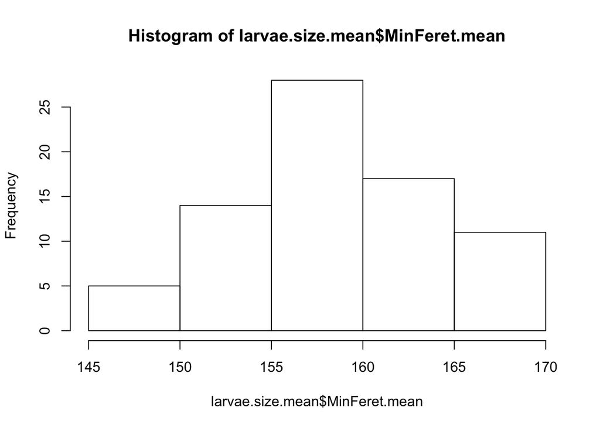

```r
hist(larvae.size.mean$MinFeret.mean)
```

```r
shapiro.test(larvae.size.mean$MinFeret.mean)
```

```
##
##  Shapiro-Wilk normality test
##
## data:  larvae.size.mean$MinFeret.mean
## W = 0.99115, p-value = 0.8854
```

```r
bartlett.test(MinFeret.mean ~ pH, data=larvae.size.mean)
```

```
##
##  Bartlett test of homogeneity of variances
##
## data:  MinFeret.mean by pH
## Bartlett's K-squared = 1.9133, df = 1, p-value = 0.1666
```

```r
bartlett.test(MinFeret.mean ~ Temperature, data=larvae.size.mean)
```

```
##
##  Bartlett test of homogeneity of variances
##
## data:  MinFeret.mean by Temperature
## Bartlett's K-squared = 0.51483, df = 1, p-value = 0.4731
```

```r
anova(lm(MinFeret.mean ~ Temperature + pH + Temperature:pH, data=larvae.size.mean)) #no interaction. Assess using type II sums of squares, where I look at effects of pH and temperature after controlling for the other factor
```

```
## Analysis of Variance Table
##
## Response: MinFeret.mean
##                Df  Sum Sq Mean Sq F value   Pr(>F)
## Temperature     1  160.69 160.693  6.5691 0.012497 *
## pH              1  175.97 175.967  7.1935 0.009094 **
## Temperature:pH  1   18.42  18.418  0.7529 0.388480
## Residuals      71 1736.79  24.462
## ---
## Signif. codes:  0 '***' 0.001 '**' 0.01 '*' 0.05 '.' 0.1 ' ' 1
```

```r
Anova(lm(MinFeret.mean ~ Temperature*pH, data=larvae.size.mean), type=2) #both sign.
```

```
## Anova Table (Type II tests)
##
## Response: MinFeret.mean
##                 Sum Sq Df F value   Pr(>F)
## Temperature     245.16  1 10.0222 0.002279 **
## pH              175.97  1  7.1935 0.009094 **
## Temperature:pH   18.42  1  0.7529 0.388480
## Residuals      1736.79 71
## ---
## Signif. codes:  0 '***' 0.001 '**' 0.01 '*' 0.05 '.' 0.1 ' ' 1
```

```r
summary(lm(MinFeret.mean ~ Temperature+pH, data=larvae.size.mean)) # Fit not great, though
```

```
##
## Call:
## lm(formula = MinFeret.mean ~ Temperature + pH, data = larvae.size.mean)
##
## Residuals:
##      Min       1Q   Median       3Q      Max
## -12.8673  -3.0864  -0.0883   3.0507   9.3975
##
## Coefficients:
##               Estimate Std. Error t value Pr(>|t|)
## (Intercept)    154.786      1.140 135.832  < 2e-16 ***
## Temperature10    3.750      1.182   3.171  0.00223 **
## pHlow            3.172      1.181   2.687  0.00896 **
## ---
## Signif. codes:  0 '***' 0.001 '**' 0.01 '*' 0.05 '.' 0.1 ' ' 1
##
## Residual standard error: 4.937 on 72 degrees of freedom
## Multiple R-squared:  0.1609, Adjusted R-squared:  0.1376
## F-statistic: 6.905 on 2 and 72 DF,  p-value: 0.001806
```

Try mixed effect model, with Population as random effect

```r
display(lmer(MinFeret.mean ~ Temperature*pH + (1|Population), data=larvae.size.mean))
```

```
## lmer(formula = MinFeret.mean ~ Temperature * pH + (1 | Population),
##     data = larvae.size.mean)
##                     coef.est coef.se
## (Intercept)         155.11     1.56
## Temperature10         2.54     1.70
## pHlow                 2.21     1.71
## Temperature10:pHlow   2.17     2.31
##
## Error terms:
##  Groups     Name        Std.Dev.
##  Population (Intercept) 1.39
##  Residual               4.78
## ---
## number of obs: 75, groups: Population, 4
## AIC = 449.8, DIC = 456
## deviance = 446.9
```

```r
Anova(lmer(MinFeret.mean ~ Temperature*pH + (1|Population), data=larvae.size.mean), type=2)
```

```
## Analysis of Deviance Table (Type II Wald chisquare tests)
##
## Response: MinFeret.mean
##                  Chisq Df Pr(>Chisq)
## Temperature    10.3803  1   0.001274 **
## pH              8.7864  1   0.003035 **
## Temperature:pH  0.8886  1   0.345857
## ---
## Signif. codes:  0 '***' 0.001 '**' 0.01 '*' 0.05 '.' 0.1 ' ' 1
```

```r
display(lmer(MinFeret.mean ~ Temperature+pH+ (1|Population), data=larvae.size.mean))
```

```
## lmer(formula = MinFeret.mean ~ Temperature + pH + (1 | Population),
##     data = larvae.size.mean)
##               coef.est coef.se
## (Intercept)   154.34     1.32
## Temperature10   3.72     1.15
## pHlow           3.40     1.15
##
## Error terms:
##  Groups     Name        Std.Dev.
##  Population (Intercept) 1.38
##  Residual               4.77
## ---
## number of obs: 75, groups: Population, 4
## AIC = 452.2, DIC = 453.4
## deviance = 447.8
```

```r
Anova(lmer(MinFeret.mean ~ Temperature+pH + (1|Population), data=larvae.size.mean), type=2) #with Pop as random effect and using type II SS, still sign. influence of temp and pH
```

```
## Analysis of Deviance Table (Type II Wald chisquare tests)
##
## Response: MinFeret.mean
##               Chisq Df Pr(>Chisq)
## Temperature 10.3913  1   0.001266 **
## pH           8.7842  1   0.003039 **
## ---
## Signif. codes:  0 '***' 0.001 '**' 0.01 '*' 0.05 '.' 0.1 ' ' 1
```

#### Test sign. diff among cohorts only

```r
summary(aov(MinFeret.mean ~ Population, data=larvae.size.mean)) #no
```

```
##             Df Sum Sq Mean Sq F value Pr(>F)
## Population   3  153.5   51.15   1.874  0.142
## Residuals   71 1938.4   27.30
```

```r
summary(aov(MaxFeret.mean ~ Population, data=larvae.size.mean)) #no
```

```
##             Df Sum Sq Mean Sq F value Pr(>F)
## Population   3  203.7   67.90   1.929  0.133
## Residuals   71 2499.8   35.21
```

### Check out larval sizes for samples I already sequenced last year

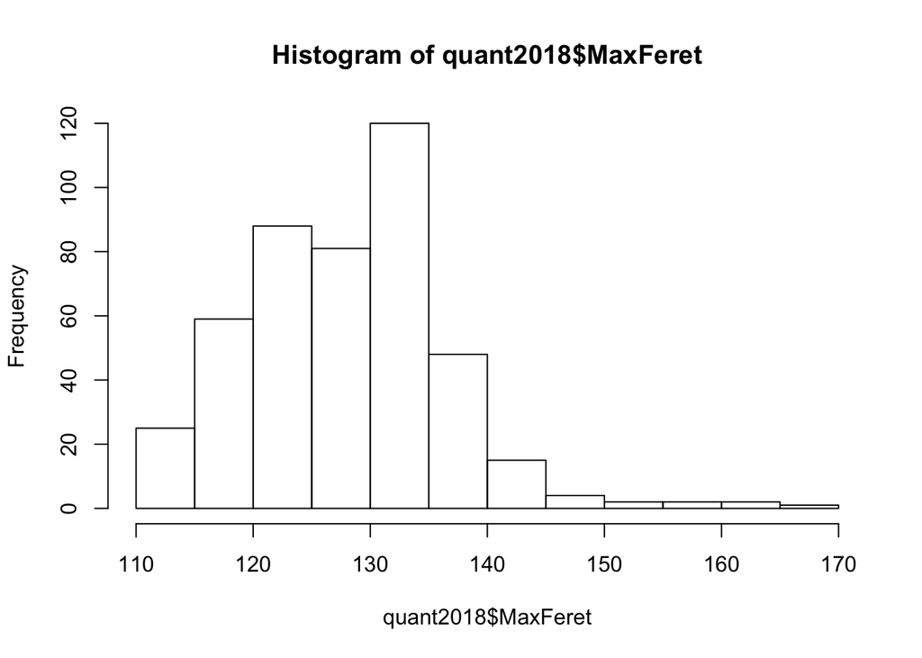

```r
quant2018 <-  as.factor(c(41, 26, 32, 10, 48, 77)) #sample numbers for larvae already sequenced (only n=3 per treat)
quant2018 <- larvae.size[larvae.size$Sample %in% quant2018,]
hist(quant2018$MaxFeret)
```

```r
shapiro.test(log(quant2018$MaxFeret))
```

```
##
##  Shapiro-Wilk normality test
##
## data:  log(quant2018$MaxFeret)
## W = 0.97852, p-value = 3.588e-06
```

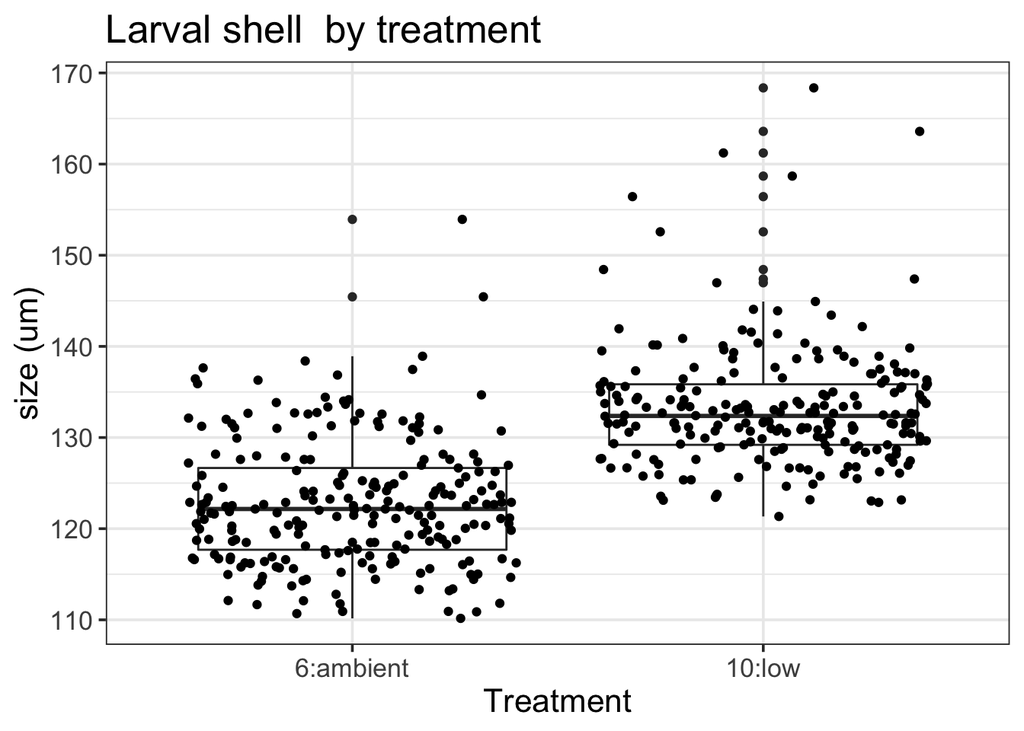

```r
ggplot(quant2018, aes(x=Temperature:pH, y=MaxFeret)) + geom_boxplot() + geom_jitter() + theme_bw(base_size = 14) + labs(title="Larval shell  by treatment", y=("size (um)"), x="Treatment") + theme(text = element_text(size = 16))
```

```r
kruskal.test(quant2018$MaxFeret, g = quant2018$pH) #sign. different - 10-low larger.
```

```
##
##  Kruskal-Wallis rank sum test
##
## data:  quant2018$MaxFeret and quant2018$pH
## Kruskal-Wallis chi-squared = 187.42, df = 1, p-value < 2.2e-16
```